\pagebreak

# Abundance, Age, and Condition of Rainbow Trout at Black Bear Lake, Southeast Alaska

## *Summer 2002 Monitoring at the Black Bear Lake Hydroelectric Project, Near Klawock, Prince of Wales Island, Alaska*

### Author: Bernard T Romey

### Date: May 2014

### Executive Summary

This report summarizes results of population, age, size, and condition factor investigations for rainbow trout conducted during July 2002 for use in the evaluation of the Black Bear Lake Hydroelectric Project, near Klawock, Alaska.

Fyke-net traps and hoop traps were used to sample Black Bear Lake. Rainbow trout (Oncorhynchus mykiss) captured in the gear were marked to facilitate a mark-recapture experiment to estimate trout abundance. An estimated 993 (SE = 59.57) rainbow trout r >= 180 mm FL were present in 2002.

Based on age analysis information (Romey 2002), age 5 (1997 brood year) was the most abundant year class. Most trout sampled in Black Bear Lake in 2002 were age 4 or 5. The low abundance of age 3 fish was indicative of poor recruitment from the 1999 brood year.

Fish condition factor and length-weight relationships were computed from fish captured by fyke and hoop traps. Relative fish condition in 2002 was the second highest during the 7 years of monitoring. This suggests that food supply and other environmental factors are favorable for fish growth.

\pagebreak

### Introduction

Black Bear Lake Hydro, Inc. (BBLH), a subsidiary of Alaska Power & Telephone Company (AP&T), presently operates a federally-licensed 4.5-megawatt hydroelectric project (Federal Energy Regulatory Commission [FERC] License No. 10440-001) that generates power for the cities of Craig and Klawock, and the majority of other smaller communities on Prince of Wales Island (Figure 1). This project transfers water from Black Bear Lake, via a siphon and buried/surface penstock, to a powerhouse located downstream along Black Bear Creek. Black Bear Lake provides a portion of the flow to Black Bear Creek via a lake outlet stream that goes sub-surface and then re-emerges, as an upwelling, a short distance downstream. The water surface level in Black Bear Lake fluctuates throughout the year in response to drawdown from power generation and to seasonal changes in runoff. The maximum drawdown allowed by the FERC license is 4.6 m (15 ft). Water levels in Black Bear Creek also fluctuate in response to the hydroelectric operation.

Limited information from past studies is available to determine rainbow trout population age composition and abundance in Black Bear Lake during spring and summer periods when spawning habitat may be limited due to lake drawdown. Regulated flows and lake drawdown from the BBLH Project change the amount of available habitat during spawning, incubation, and rearing for rainbow trout. Based on lake-level data supplied by BBLH, trapping data from the 1997 population estimate study (Martin Environmental 1998), and length-at-age data (Environaid 1982), there appeared to be recruitment to the lake population even when the lake outlet was dewatered during spawning and incubation, but age analysis and spawning observations were cursory and incomplete. Further information was needed to determine age distribution and adult population status.

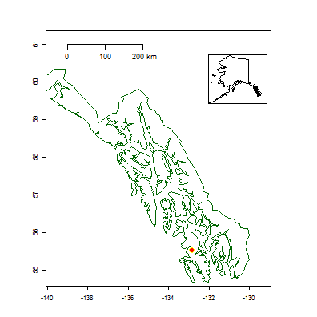

### Study Area

Black Bear Lake is a deep cirque lake located in steep mountainous terrain near Klawock, Prince of Wales Island, Southeast Alaska (Figure 1, and 2). The lake is 2.4 km long and varies in width from 150 to 643 m. It has a surface area of 87 ha, a volume of 27.14 ha<sup>3</sup> and a maximum depth of 69 m. The shoreline consists primarily of steep bedrock and large boulder, although there are some gravels suitable for spawning near the lake outlet and other small areas around the shoreline. The outlet stream falls approximately 427 m over a distance of approximately 530 m to the lower valley floor and forms a source for Black Bear Creek (HDR Engineering 1991), which drains into Black Lake. The USFWS stocked Black Bear Lake with rainbow trout from Washington State in 1956 to initiate a sport fishery.

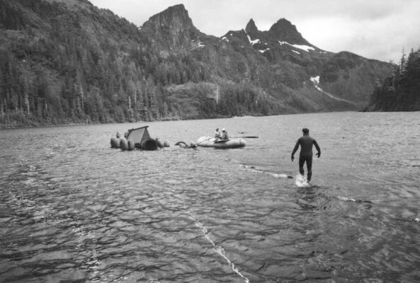

### Field Data Collection

A two-event mark-recapture experiment was used to estimate the abundance, condition, and age composition for rainbow trout in Black Bear Lake. The first sampling event (mark event) occurred from July 2 to July 12, 2002, and the second (capture event) occurred from July 24 to July 30, 2002.

All trout caught during the marking event were marked with an upper caudal fin-clip and all trout >= 180 mm fork length (FL) also had a numbered anchor tag attached. In each sample, all rainbow trout were measured to the nearest mm FL and weighed to the nearest gram.

Floy tags were inserted on the left side of the fish immediately below the dorsal fin. Secondary marks included shallow clips (notches) of the upper (marking event) and lower (recapture event) caudal fin as controls against tag loss.

During the capture event, fish were examined for a mark (either a caudal fin-clip or a numbered anchor tag). Rainbow trout < 180 mm FL captured during the second sampling event were only counted and released.

The lake was divided into three areas of roughly equal size to help evaluate the experimental assumptions for the closed population (CP) experiment. The three sampling areas (A, B, and C) were each further subdivided into two sub-areas so that daily sampling could proceed systematically from one end of the lake to the other. During each six-day sampling event, six baited hoop traps (BHT) were systematically moved through the six sub-areas on a daily basis so that the total amount of gear set was uniformly distributed across all areas of the lake.

Baited hoop traps were 1.4 m long and consisted of four 0.6 m-diameter hoops with 9 cmdiameter throats attached to the first and third hoops. Traps were constructed of knotless nylon netting with a mesh size of 1 cm. Salmon eggs disinfected in a 1% betadine solution for 15 minutes were used as bait within each trap. Traps were set overnight, and the depth at which each BHT was set was measured to the nearest 0.01 m. Fyke nets were 2.7 m (9 ft) long, 91.4 cm (36 in) in diameter, and had two 0.9 mX 6.1 m (3 ft X 20 ft) wings. Internal throats, body, and wings were of 0.48 cm (3/16 in) square-mesh knotless nylon.

### Data Analysis

#### *Population*

A CP two-event mark-recapture experiment was used to estimate the abundance, length and age composition for the rainbow trout population >= 180 mm FL in the summer of 2002. The >= 180 mm FL cut-off point is used in similar studies in Southeast Alaska (e.g., Harding et al. 1999). Six-day sampling events were conducted in July 2002.

Chapmans modification of the Petersen estimator (Seber 1982) was used to estimate abundance \( (N) \) of rainbow trout:

> \( (N) = (M+1)(C+1)/(R+1) \)

with variance:

> \( V(N) = (M+1)(C+1)(M-R)(C-R)/(R+1)^2 (R+2) \)

where:

> \( M \) = number of tagged fish released during the first event,

> \( C \) = number of fish examined for tags during the second event, and

> \( R \) = number of tagged fish recaptured during the second event.

The two-event CP Peterson model requires the following assumptions necessary for this procedure:

1. marking did not affect the catchability of a fish;
2. the population was closed, in that there was no change in the number of fish in the population between sampling events (no mortality, emigration or immigration);
3. there was no tag loss, and all marks were recognized during the second sampling event; and
4. all fish had the same probability of capture in the marking event or in the recapture event, or marked and unmarked fish mixed completely between events.

#### *Condition Factor*

Length and weight data from captured fish were used to calculate a length-weight relationship and a relative condition factor (Bagenal 1968). The length-weight relationship was calculated by plotting log(weight) against log(length), then fitting a regression line to the points using the least squares technique. The regression coefficient and intercept were then calculated. The relative condition factor (\( K \)) was calculated by the following formula:

> \( K = 10^N W/L^3 \)

Where:

> \( K \) is the Condition Factor of the Coefficient of Condition.

> \( W \) is the weight of the fish in grams (g).

> \( L \) is the lenght of the fish in millimetres (mm).

> \( N=5 \); Set at 5 for salmonids.

For salmonids, \( K \) values usually fall in the range of 0.8 to 2.0.

\pagebreak

The results were multiplied by 100,000 to provide an appropriate scaling to the values (Anderson and Gutreuter 1983).

### Results

#### *Size and Age*

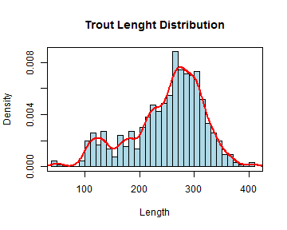

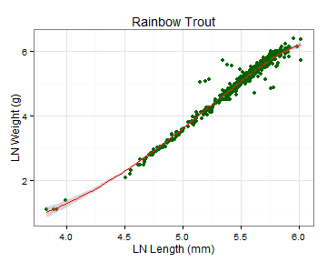

Table 2. Linear Model.

[output not shown]

\pagebreak

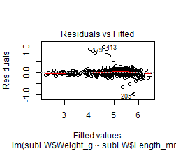

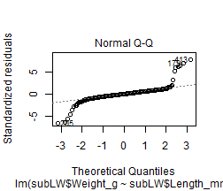

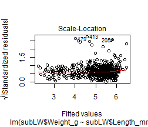

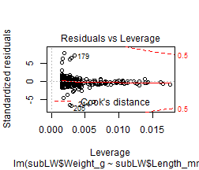

#### *Population*

A two-sample Kolmogrov-Smirnov (KS) test (Zar 1996) was used to detect significant differences in the lengths of fish >= 180 mm FL caught during the different sampling events. The length-distributions of rainbow trout initially captured during the marking event and then recaptured during the recapture event were not significantly different (KS test, Dmax = 0.0686, P = 0.82). Therefore, stratification based on fish size for the purpose of estimating population size was not required.

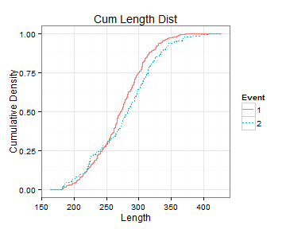

The hypothesis of equal probability of capture by area was rejected (P = 0.04), and so was the hypothesis that marked fractions were similar in each recovery stratum (P < 0.01). However, since partial mixing of marked fish between sampling areas did occur between sampling events, spatial data for the entire study area were pooled and the Chapman modification of the Petersen model was used to estimate abundance.

Abundance of rainbow trout >= 180 mm FL in Black Bear Lake in July 2002 was estimated at 993 (SE = 59.57). The 95% confidence interval (CI) for the estimate was 876 to 1110.

### Discussion

#### *Age and Condition*

Age composition for 2002 suggests a strong age 5 component in the population. This information suggests that when the outlet stream was dewatered during 1997, there was still recruitment to the population from other areas of the lake for that brood year. Age 3 fish were less abundant than ages 2 and 4 fish, indicating that recruitment from the 1999 brood year was lower than from 1998 and 2000. Since the hydroelectric project operations began in 1996, the outlet stream has been dewatered on many occasions during the spawning period, yet recruitment for all brood years was present in the population. This indicates that during times of outlet stream dewatering, some recruitment comes primarily from beach spawning areas at lower lake depths.

An estimate of fry emergence date was determined using the Accumulated Thermal Units (ATU's), or cumulative total of the daily temperatures, during the egg incubation period. We used July 2 as our starting date, since this was the first day we observed trout spawning in the outlet channel, and a completion date of July 28, when our last survey was conducted for new redds. Since we only had water temperature data for July, an average temperature of 9.0ºC for all observed spawning habitat areas was used as a rough estimate for ATUs. Thus, the majority of fry contributing to the population in the fall should have emerged by approximately September 26, 2002.

The amount of time between emergence and the onset of winter leaves very little time for these fry to grow. This was confirmed with catch data for age 1 fish (2001 cohort) having a mean length of 52 mm FL and no observed annulus during aging.

A comparison of relative fish condition factor (\( K \)) indicated that condition had increased in 2002 compared to the previous 5 years and was the second highest during the 7 years of monitoring. Fish condition since hydroelectric operations began in 1996 has shown a steady increase. This suggests that food supply and environmental conditions are favorable for fish growth.

The condition of most fish caught during this study were between 0.98 and 1.11 (Figure 7), while the mean condition for the sampled population was 1.05. Even though a comparison between years indicates improved condition, the relative condition of the fish compared to other healthy populations is poor. This is primarily a result of very little predation and limited food due to an oligotrophic isolated alpine cirque lake habitat.

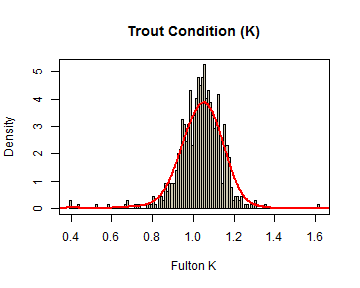

Timing of field observations should also be considered when comparing relative mean condition factors among years. Post-spawning fish weight for both males and females will decrease slightly. In past studies (Konopacky Environmental 1993b, 1995a, 1995b; Martin Environmental 1996, 1997, 1999), fish were sampled during the last week of July, after the majority of spawning had ended. During this study, a large percentage of the fish were sampled during the first two weeks of July, while spawning was ongoing. Sampling in early July may be partially responsible for the second highest relative condition on record since 1993.

#### *Population*

The accurate use of the Petersen estimators requires several assumptions, including that both immigration and emigration (or death) do not occur during the experiment. We minimized the likelihood of a significant violation of this assumption by keeping the two sampling events relatively close together.

Another assumption is that all fish have the same probability of capture during the first sampling **or** in the second sample **or** that marked and unmarked fish mix completely between the two sampling events. Because the majority of the lake-shore is too steep to deploy fyke-net traps, the effect of only being able to deploy the nets in limited locations adds bias to the population estimate; particularly since a large percentage of fish were caught in the fyke-net traps.

Consequently, assumptions of the experiment were tested with reduced power and the likelihood of bias. While the direction of the bias in the population estimate is unknown, we felt that a moderate loss of relative precision would not compromise the basic results and implications of this study.

In 2002, Black Bear Lake had the fifth largest (N = 993) rainbow trout population on record during the 7 years of monitoring. This is a conservative estimate since fish < 180 mm were not included in the estimate. From our observations it is felt that the true population value probably lies on the upper side of the population estimate, possibly in the region of 1,000 to 1,100 fish. In addition, the 95% CI for the 2002 estimate was the smallest for all years of monitoring, indicating that a mark-recapture study is a reasonable method for comparing population differences among years for fish >180 mm.

\pagebreak

### References

Anderson, R. O., and S. J. Gutreuter. 1983. Length, weight, and associated structural indices. In: L.A. Nielsen, D. L. Johnson, and S. S. Lampton (eds). Fisheries Techniques. American Fisheries Society, Bethesda, Maryland.

Dowdey, S., and S. Wearden. 1991. Statistics for research. 2nd ed. John Wiley & Sons, New York.

Environaid. 1982. Late-summer and fall observations in upper Black Bear Creek and Black Bear Lake.

Fulton, T. 1902. Rate of growth of seas fishes. Sci. Invert. Fish. Div. Scot. Rept. 20.

Konopacky Environmental. 1993a. Proposed plans for Black Bear Lake rainbow trout population, bald eagle nest tree, and spotted frog presence-absence studies associated with the proposed Black Bear Lake Hydroelectric Project near Klawock, Prince of Wales Island, Southeast Alaska. Submitted to Alaska Power & Telephone, Port Townsend, Washington.

Konopacky Environmental. 1993b. Rainbow trout population, bald eagle nest tree, and spotted frog presence-absence studies associated with the proposed Black Bear Lake Hydroelectric Project near Klawock, Prince of Wales Island, Southeast Alaska. Submitted to Alaska Power & Telephone, Port Townsend, Washington.

Konopacky Environmental. 1995a. Second year of a five-year study of the rainbow trout population in Black Bear Lake, conducted in association with the FERC-licensed Black Bear Lake Hydroelectric Project near Klawock, Prince of Wales Island, Alaska, during 1994. Submitted to Alaska Power & Telephone, Port Townsend, Washington.

Konopacky Environmental. 1995b. Third year (1995) of a five-year study of the rainbow trout population in Black Bear Lake, conducted in association with the FERC-licensed Black Bear Lake Hydroelectric Project, near Klawock, Prince of Wales Island, Alaska. Submitted to Alaska Power & Telephone, Port Townsend, Washington.

Martin Environmental. 1996. Fourth year (1996) of a five-year study of the rainbow trout population in Black Bear Lake, conducted in association with the FERC-licensed Black Bear Lake Hydroelectric Project near Klawock, Prince of Wales Island, Alaska. Submitted to Alaska Power & Telephone, Port Townsend, Washington.

Martin Environmental. 1997. Fifth year (1997) of a five-year study of the rainbow trout population in Black Bear Lake, conducted in association with the FERC-licensed Black Bear Lake Hydroelectric Project near Klawock, Prince of Wales Island, Alaska. Submitted to Alaska Power & Telephone, Port Townsend, Washington.

Martin Environmental. 1998. An assessment of a five-year (1993-1997) monitoring study of the rainbow trout population in Black Bear Lake, conducted in association with the FERC-licensed Black Bear Lake Hydroelectric Project near Klawock, Prince of Wales Island, Alaska. Submitted to Alaska Power & Telephone, Port Townsend, Washington.

Martin Environmental. 1999. Rainbow trout population in Black Bear Lake, results from the sixth year (1998) of monitoring at the Black Bear Lake Hydroelectric Project, Near Klawock, Prince of Wales Island, Alaska. Submitted to Alaska Power & Telephone, Port Townsend, Washington.

Romey, B.T. 2002. Abundacnce, Age, Size, and Lake-shore Spawning of Rainbow Trout at Black Bear Lake, Southeast Alaska. Report to Black Bear Lake Hydro, Inc., for Summer 2002 Monitoring at the Black Bear Lake Hydroelectric Project, Near Klawock, Prince of Wales island, Alaska.

Seber, G. A. F. 1982. The estimation of animal abundance and related-parameters, second edition. Charles Griffin and Company, Limited. London.

Zar, J. H. 1996. Biostatistical analysis. 3rd ed. Prentice Hall, Englewood Cliffs, New Jersey.